# Análise de Clusters

## Padrões relativamente a satisfação dos clientes com o serviço prestado

No sentido de avaliar as caracteristicas que os clientes mais valorizam no serviço prestado pela YFT recorreu-se aos dados do questionário que a empresa possui para recolher o feedback dos clientes relativamente aos seguintes aspetos:

| **Feedback.csv** | **Questionário** |
| --- | --- |
| **Your Arrival** |  |
| welcome_arrival | How was our welcome at the airport? |
| punctual_arrival | How punctual was your driver at the airport? |
| clean_in_arrival | How clean was the interior of your Yellowfish vehicle? |
| clean_out_arrival | How clean was the exterior of your Yellowfish vehicle? |
| driving_arrival | How was the driving experience to your resort? |
| curteous_arrival | How friendly was your driver? |
| boot_arrival | Was the vehicle boot big enough for your luggage? |
| wifi_arrival |  |
| **Our booking process** |  |
| website | How easy was it to book with Yellowfish? |
| **In General** |  |
| experience |  |
| **Anything else to add?** |  |
| comments |  |
| **Your Departure** |  |
| welcome_departure | How was our welcome at the airport? |
| clean_in_departure | How clean was the interior of your Yellowfish vehicle? |
| clean_out_departure | How clean was the exterior of your Yellowfish vehicle? |
| punctual_departure | How punctual was your driver at the airport? |
| driving_departure | How was the driving experience to your resort? |
| curteous_departure | How friendly was your driver? |
| boot_ departure | Was the vehicle boot big enough for your luggage? |
| wifi_departure |  |
| freegift |  |
| quality |  |

```r
library("RODBC")
library("dplyr")
library("ggplot2")
library(clustertend)
library("factoextra")
library("NbClust")
library("fpc")
library("dendextend")
library(tidyr)
library(cluster)
library(psych)
library(reshape)
#install.packages("kableExtra")
library(kableExtra)
#install.packages("fmsb")
library(fmsb)
library(skimr)
#install.packages("corrplot")
library(corrplot)
library(GGally)
library(dplyr)
# You need the MASS library
library(MASS)
# Vector color
library(RColorBrewer)
library("Rtsne")
#install.packages("countrycode")
library(countrycode)
#reorder_within() a function originally wrote it by David Robinson and now included in the tidytext package.
#install.packages("tidytext")
library(tidyverse)
library(tidytext)
library(lemon)

options(warn=-1)
#options(warn=0)
```

[output not shown]

```r
#Bartlett’s sphericity test: Tests the hypothesis that correlations between variables are greater
#than would beexpected by chance: Technically, tests if the matrix is an identity matrix.

#The p-value should be significant:i.e., the null hypothesis that all off-diagonal correlations are zero is falsified.

#Prof. Shigenobu Aoki provides the following function to conduct Bartlett’s sphericity test at his web page:

Bartlett.sphericity.test <- function(x){
    method <- "Bartlett’s test of sphericity"
    data.name <- deparse(substitute(x))
    x <- subset(x, complete.cases(x)) # Omit missing values
    n <- nrow(x)
    p <- ncol(x)
    chisq <- (1-n+(2*p+5)/6)*log(det(cor(x)))
    df <- p*(p-1)/2
    p.value <- pchisq(chisq, df, lower.tail=FALSE)
    names(chisq) <- "X-squared"
    names(df) <- "df"
    return(structure(list(statistic=chisq, parameter=df, p.value=p.value,method=method, data.name=data.name), class="htest"))
}
```

### Leitura do Dataset "Feedback.csv" a partir da base de dados Sql

```r
#feedback <- read.csv(file.choose(), sep=";", fill = T)
conn <- odbcDriverConnect('driver={SQL Server};server=LT122290;database=YFT_V2;trusted_connection=true')
```

```r
feedback <- sqlQuery(conn, "select book_id, codigo,
cast([welcome_arrival] as numeric) [welcome_arrival],
cast([welcome_departure] as numeric)[welcome_departure],
cast([punctual_arrival] as numeric)[punctual_arrival],
cast([clean_in_arrival] as numeric)[clean_in_arrival],
cast([clean_out_arrival] as numeric)[clean_out_arrival],
cast([clean_in_departure] as numeric)[clean_in_departure],
cast([clean_out_departure] as numeric)[clean_out_departure],
cast([punctual_departure] as numeric)[punctual_departure],
cast([driving_arrival] as numeric)[driving_arrival],
cast([driving_departure] as numeric)[driving_departure],
cast([curteous_arrival] as numeric)[curteous_arrival],
cast([curteous_departure] as numeric)[curteous_departure],
cast([website] as numeric)[website],
cast([experience] as numeric)[experience],
cast([quality] as numeric)[quality],
cast([freegift] as numeric)[freegift],
cast([wifi_arrival]as numeric)[wifi_arrival],
cast([wifi_departure]as numeric)[wifi_departure],
cast([boot_arrival]as numeric)[boot_arrival],
cast([boot_departure]as numeric)[boot_departure]
from  [dbo].[SA_28MAR_feedback]
--where  timer !='NULL'
")
```

O quadro seguinte apresenta as estatísticas descritivas das variáveis originais.

- Exitem 84122 respostas
- Não existem valores omissos
- Repare-se que as variáveis em análise não são quantitativas mas são tratadas como tal (são medidas em escalas de Likert).

```r
skim(feedback)
```

```
-- Data Summary ------------------------
                           Values
Name                       feedback
Number of rows             84122
Number of columns          22
_______________________
Column type frequency:
  factor                   1
  numeric                  21
________________________
Group variables            None

-- Variable type: factor -------------------------------------------------------
# A tibble: 1 x 6
  skim_variable n_missing complete_rate ordered n_unique
* <chr>             <int>         <dbl> <lgl>      <int>
1 codigo                0             1 FALSE          4
  top_counts
* <chr>
1 RAL: 66467, OLA: 9743, OAL: 7911, OLL: 1

-- Variable type: numeric ------------------------------------------------------
# A tibble: 21 x 11
   skim_variable       n_missing complete_rate       mean        sd    p0   p25
 * <chr>                   <int>         <dbl>      <dbl>     <dbl> <dbl> <dbl>
 1 book_id                     0             1 173453.    95279.      130 92980
 2 welcome_arrival             0             1      4.52      1.33      0     5
 3 welcome_departure           0             1      1.56      2.30      0     0
 4 punctual_arrival            0             1      4.33      1.64      0     5
 5 clean_in_arrival            0             1      4.60      1.21      0     5
 6 clean_out_arrival           0             1      4.59      1.21      0     5
 7 clean_in_departure          0             1      1.60      2.32      0     0
 8 clean_out_departure         0             1      1.60      2.32      0     0
 9 punctual_departure          0             1      4.42      1.52      0     5
10 driving_arrival             0             1      4.28      1.64      0     5
11 driving_departure           0             1      4.38      1.52      0     5
12 curteous_arrival            0             1      4.31      1.64      0     5
13 curteous_departure          0             1      4.42      1.51      0     5
14 website                     0             1      4.64      0.972     0     5
15 experience                  0             1      6.62      2.52      0     5
```

[output cut: 14 more lines]

```
 7      0      5       5 ▇▁▁▁▃
 8      0      5       5 ▇▁▁▁▃
 9      5      5       5 ▁▁▁▁▇
10      5      5       5 ▁▁▁▁▇
11      5      5       5 ▁▁▁▁▇
12      5      5       5 ▁▁▁▁▇
13      5      5       5 ▁▁▁▁▇
14      5      5       5 ▁▁▁▁▇
15      5     10      10 ▁▁▇▁▅
16      5      5       5 ▆▁▁▂▇
17      0      0       5 ▇▁▁▁▂
18      0      0       5 ▇▁▁▁▁
19      0      0       5 ▇▁▁▁▁
20      0      3       5 ▇▁▁▁▂
21      0      4       5 ▇▁▁▁▃
```

```r
#data <- scale(feedback[,4:19])
data <- scale(feedback[, 3:22])
grupo_data <- as.factor(feedback[, 2])

# retirar uma amostra dos dados
data_sample <- sample_frac(data.frame(feedback), 0.1)
grupo_data_sample <- as.factor(data_sample[, 2])
data_sample <- scale(data_sample[, 3:22])
#data <-feedback
```

### Estatística alpha de Cronbach para estimar a confiabilidade do questionário

A estatística alpha de Cronbach avalia a consistência interna das respostas (proporção da variabilidade nas respostas que resulta de diferenças nos inquiridos).

Classificação da consistência interna conforme os valores do alpha de Cronbach

| > ou = 0,90 | Excelente |
| --- | --- |
| ]0,80; 0,90] | Boa |
| ]0,70; 0,80] | Razoável |
| ]0,60; 0,70] | Fraca |
| <0,60 | Inaceitável |

```r
psych::alpha(data, check.keys=TRUE)
```

```
Reliability analysis
Call: psych::alpha(x = data, check.keys = TRUE)

  raw_alpha std.alpha G6(smc) average_r S/N     ase  mean   sd median_r
      0.85      0.85    0.97      0.22 5.5 0.00077 -0.26 0.51     0.12

 lower alpha upper     95% confidence boundaries
0.85 0.85 0.85

 Reliability if an item is dropped:
                    raw_alpha std.alpha G6(smc) average_r S/N alpha se var.r
welcome_arrival-         0.83      0.83    0.96      0.21 5.0  0.00083 0.095
welcome_departure        0.82      0.82    0.96      0.20 4.7  0.00089 0.093
punctual_arrival-        0.84      0.84    0.96      0.21 5.1  0.00081 0.093
clean_in_arrival-        0.83      0.83    0.96      0.21 5.0  0.00084 0.095
clean_out_arrival-       0.83      0.83    0.96      0.21 5.0  0.00084 0.095
clean_in_departure       0.82      0.82    0.96      0.20 4.7  0.00089 0.092
clean_out_departure      0.82      0.82    0.96      0.20 4.7  0.00089 0.092
punctual_departure       0.85      0.85    0.96      0.22 5.5  0.00077 0.095
driving_arrival-         0.84      0.84    0.96      0.21 5.2  0.00081 0.092
driving_departure        0.85      0.85    0.96      0.22 5.5  0.00077 0.095
curteous_arrival-        0.84      0.84    0.96      0.21 5.1  0.00081 0.092
curteous_departure       0.85      0.85    0.96      0.22 5.5  0.00077 0.095
website-                 0.85      0.85    0.97      0.23 5.8  0.00075 0.102
experience               0.83      0.83    0.96      0.21 5.0  0.00084 0.095
quality-                 0.85      0.85    0.97      0.23 5.7  0.00076 0.100
freegift-                0.85      0.85    0.97      0.23 5.6  0.00077 0.101
wifi_arrival             0.85      0.85    0.97      0.24 5.8  0.00074 0.096
wifi_departure           0.85      0.85    0.96      0.23 5.6  0.00076 0.098
boot_arrival             0.85      0.85    0.96      0.23 5.6  0.00077 0.090
boot_departure           0.83      0.83    0.96      0.20 4.9  0.00086 0.094
                    med.r
welcome_arrival-     0.11
welcome_departure    0.11
punctual_arrival-    0.13
clean_in_arrival-    0.12
clean_out_arrival-   0.12
clean_in_departure   0.11
clean_out_departure  0.11
punctual_departure   0.13
```

[output cut: 20 more lines]

```
clean_in_departure  84122  0.83  0.83  0.84   0.79  8.1e-17  1
clean_out_departure 84122  0.83  0.83  0.84   0.79  2.2e-16  1
punctual_departure  84122  0.36  0.36  0.36   0.27 -8.1e-17  1
driving_arrival-    84122  0.55  0.55  0.56   0.48 -5.9e-01  1
driving_departure   84122  0.37  0.37  0.37   0.28  1.8e-16  1
curteous_arrival-   84122  0.56  0.56  0.56   0.49 -5.9e-01  1
curteous_departure  84122  0.37  0.37  0.37   0.28  2.6e-16  1
website-            84122  0.23  0.23  0.14   0.13 -5.9e-01  1
experience          84122  0.64  0.64  0.63   0.58 -2.0e-16  1
quality-            84122  0.25  0.25  0.20   0.16 -5.9e-01  1
freegift-           84122  0.33  0.33  0.28   0.24 -5.9e-01  1
wifi_arrival        84122  0.19  0.19  0.16   0.09  7.9e-18  1
wifi_departure      84122  0.31  0.31  0.31   0.22  2.8e-17  1
boot_arrival        84122  0.33  0.33  0.32   0.24 -9.3e-17  1
boot_departure      84122  0.70  0.70  0.71   0.65 -2.0e-16  1
```

### Numa primeira fase da análise, pretende-se diminuir o número de variáveis por forma a poder utilizar essa informação na análises de Clusters.

### Para tal recorreu-se a uma Análise em Componentes Principais (ACP).

As componentes principais obtidas (CPs), são independentes pelo que podem ser utilizadas não só na análise de clusters mas também em análises onde a multicolinearidade (existência de correlação entre variáveis explicativas) é um problema, como é o caso da Regressão Linear Múltipla.

## Matriz de Correlações

A matriz de correlações permite procurar grupos de variáveis com correlações fortes entre si. As correlações podem ser consideradas fortes quando são superiores a 0,3. (Também se pode analisar a significância do teste cujas hipóteses são H0: Correlação entre as duas variáveis é zero vs H1: Correlação entre as duas variáveis é diferente de zero).

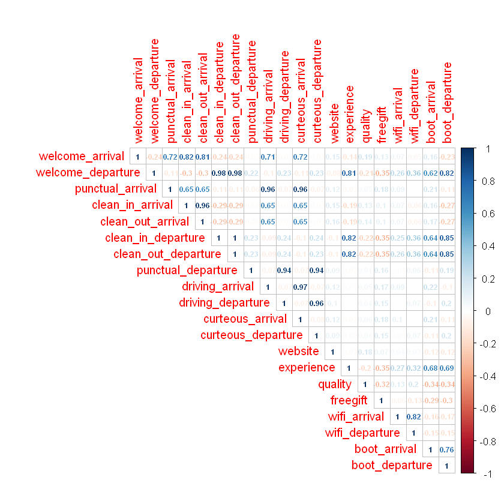

```r
corrplot(cor(data), type="upper", method = "number", number.cex = .6)
#corrplot.mixed(cor(data), lower.col = "black", number.cex = .5)
```

### Reordenação da Matriz de correlações

A Matriz de correlações é reordenada de acordo com os coeficientes de correlação.  
Esta reodenação é importante de forma a facilitar a identificação de padrões na matriz.  
No gráfico ordenado é visivel alguns grupos de variáveis fortemente correlacionadas.

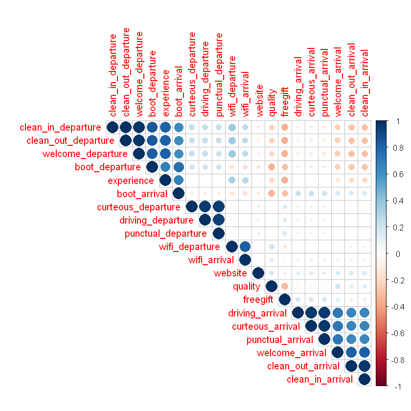

```r
corrplot(cor(data), type="upper", order="FPC")
```

# Teste de Kaiser-Meyer-Olkin e Bartlett de adequabilidade da matriz de correlações

Analise-se agora a adequabilidade da matriz de correlações através da Estatística Kaiser- Meyer-Olkin e do Teste de Bartlett:

O Teste de Bartlet permite verificar se a matriz de correlações é significativamente diferente da matriz identidade.

As Hipóteses em teste são: H0: A matriz de correlações é a matriz identidade (o que isto significa é que as correlações entre as variáveis são zero) vs H1: A matriz de correlações não é a matriz identidade. Pretende-se rejeitar H0 para poder fazer uma ACP.

Analisando a significância do teste de Bartlett, pode inferir-se que as variáveis estão correlacionadas entre si (Sig=0,000<0,05 logo rejeita-se H0).

| **Valor de KMO** | **Classificação da ACP** |
| --- | --- |
| ]0,90; 1,0] | Excelente |
| ]0,80; 0,90] | Boa |
| ]0,70; 0,80] | Média |
| ]0,60; 0,70] | Razoável |
| ]0,50; 0,60] | Má mas aceitável |
| ≤ 0,50 | Inaceitável |

Fonte: Reis, E. (1997), Estatística Multivariada

```r
Bartlett.sphericity.test(data)
KMO(data)
```

```
	Bartlett's test of sphericity

data:  data
X-squared = 2648112, df = 190, p-value < 2.2e-16
```

```
Kaiser-Meyer-Olkin factor adequacy
Call: KMO(r = data)
Overall MSA =  0.85
MSA for each item =
    welcome_arrival   welcome_departure    punctual_arrival    clean_in_arrival
               0.96                0.98                0.89                0.82
  clean_out_arrival  clean_in_departure clean_out_departure  punctual_departure
               0.82                0.86                0.86                0.86
    driving_arrival   driving_departure    curteous_arrival  curteous_departure
               0.87                0.80                0.86                0.78
            website          experience             quality            freegift
               0.73                0.92                0.62                0.76
       wifi_arrival      wifi_departure        boot_arrival      boot_departure
               0.73                0.60                0.84                0.84
```

### Analisamos gráficamente se é possivel extrair uma amostra dos dados sem perder representatividade.

Recorre-se a visualização para avaliar a representatividade da amostra.

Pela visualização dos gráficos podemos verificar que uma amostra de 10% dos dados continua a apresentar o mesmo padrão que 100% dos dados.

Repara-se que no gráfico da amostra o tipo de serviço OLL(one way Local to Local) foi removido, mas como havia apenas uma observação desse tipo de serviço, não considero impeditivo para prosseguir com a análise.

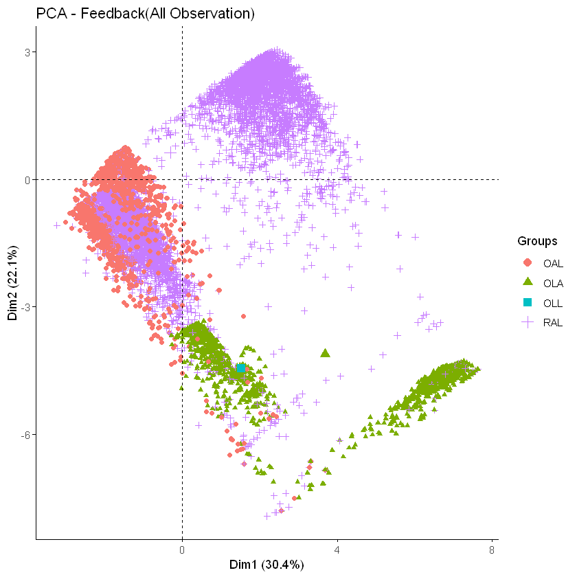

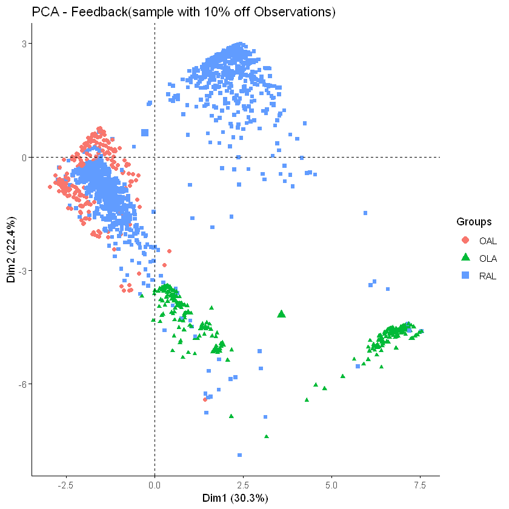

```r
#Metodo Visual
pca <- prcomp(data, scores=TRUE, cor=TRUE)
pca1 <- prcomp(data_sample, scores=TRUE, cor=TRUE)

fviz_pca_ind(pca, habillage=grupo_data, title = "PCA - Feedback(All Observation)", geom = "point", ggtheme = theme_classic())
fviz_pca_ind(pca1, habillage=grupo_data_sample, title = "PCA - Feedback(sample with 10% off Observations) ", geom = "point", ggtheme = theme_classic())
```

### Visualização da contribuição de cada variável nas duas primeiras componentes.

Este gráfico mostra a direção das observações de acordo com os loadings (contribuição de cada variável).

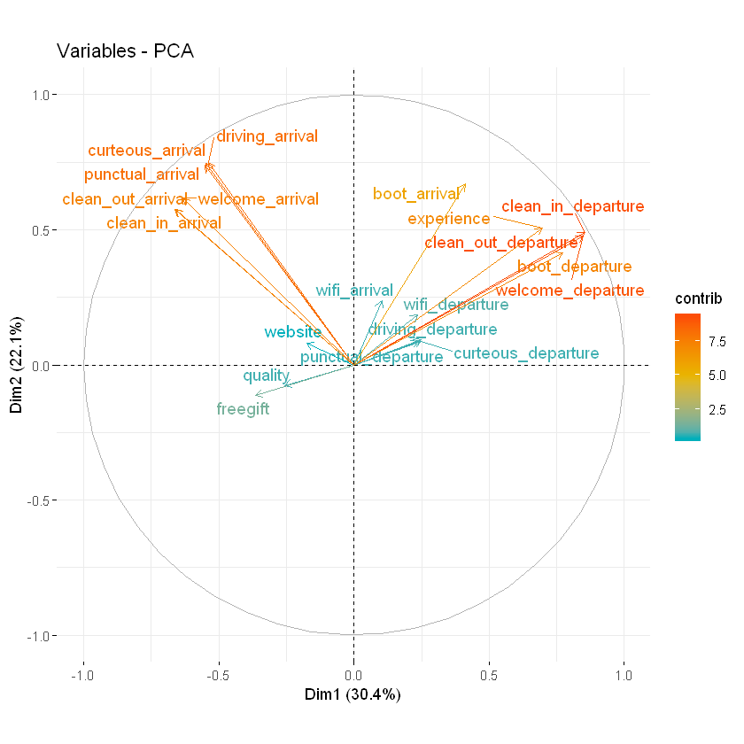

```r
fviz_pca_var(pca, col.var = 'contrib',
            gradient.cols = c('#00AFBB', '#E7B800', '#FC4E07'),
            repel = TRUE)
```

# Extracção das Componentes Principais (CP)

Quantas componentes reter? A decisão do número de componentes principais a reter depende da informação que se pode desprezar. No entanto, quantas mais componentes forem retidas, menos úteis se torna cada uma delas porque vai diminuindo o seu valor próprio.

```r
summary(pca)
```

```
Importance of components:
                          PC1    PC2    PC3    PC4    PC5     PC6     PC7
Standard deviation     2.4673 2.1041 1.7306 1.4781 1.1323 0.96664 0.87555
Proportion of Variance 0.3044 0.2213 0.1497 0.1092 0.0641 0.04672 0.03833
Cumulative Proportion  0.3044 0.5257 0.6755 0.7847 0.8488 0.89555 0.93387
                           PC8    PC9    PC10    PC11    PC12    PC13    PC14
Standard deviation     0.59413 0.4649 0.44364 0.42989 0.29595 0.25341 0.21165
Proportion of Variance 0.01765 0.0108 0.00984 0.00924 0.00438 0.00321 0.00224
Cumulative Proportion  0.95152 0.9623 0.97217 0.98141 0.98579 0.98900 0.99124
                          PC15    PC16    PC17    PC18    PC19    PC20
Standard deviation     0.20536 0.19869 0.18889 0.18032 0.14372 0.06859
Proportion of Variance 0.00211 0.00197 0.00178 0.00163 0.00103 0.00024
Cumulative Proportion  0.99335 0.99532 0.99711 0.99873 0.99976 1.00000
```

### Quantas componentes reter?

### Analise-se o Scree plot – representação gráfica dos valores próprios das componentes principais.

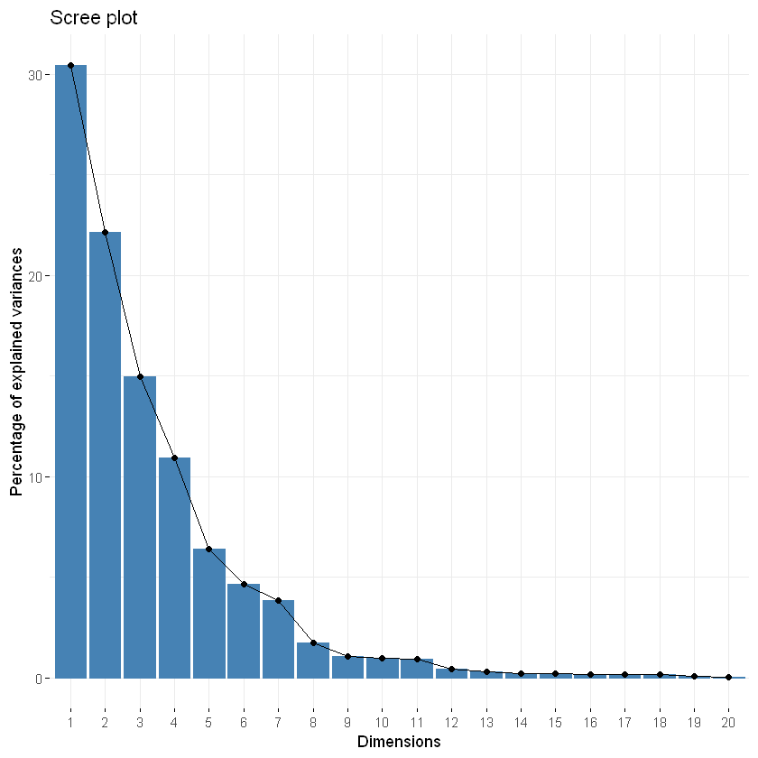

```r
fviz_screeplot(pca, ncp = 20)
```

## Visualização dos loadings de cada componente(contribuição de cada variável).

Podemos verificar pelos dados e gráficos abaixo as variáveis que mais contribuem para cada componentes:

Na CP3 a importância recai sobre aspetos relacionados com a cortesia do condutor, tipo de condução e pontualidade na partida.

Na CP4 o maior peso está nos aspetos de conforto a bordo, como o acesso a wifi.

```
Loadings:
                    PC1    PC2    PC3    PC4
welcome_arrival             0.390
welcome_departure    0.415               -0.107
punctual_arrival            0.415
clean_in_arrival            0.381
clean_out_arrival           0.381
clean_in_departure   0.421
clean_out_departure  0.421
punctual_departure                 0.556
driving_arrival             0.416
driving_departure                  0.557
curteous_arrival            0.417
curteous_departure                 0.559
website                                  -0.101
experience           0.390               -0.112
quality             -0.110               -0.317
freegift            -0.174         0.160  0.140
wifi_arrival         0.111               -0.596
wifi_departure       0.136               -0.617
boot_arrival         0.341  0.157 -0.102  0.237
boot_departure       0.370                0.232

                 PC1   PC2   PC3   PC4
SS loadings    1.024 1.001 1.006 1.020
Proportion Var 0.051 0.050 0.050 0.051
Cumulative Var 0.051 0.101 0.152 0.203
```

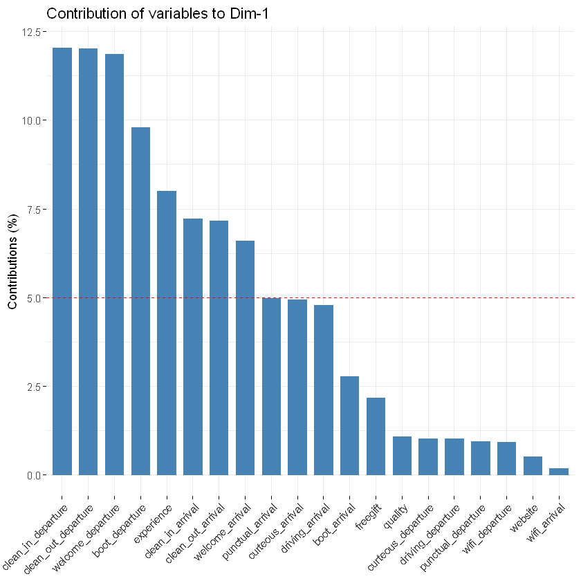

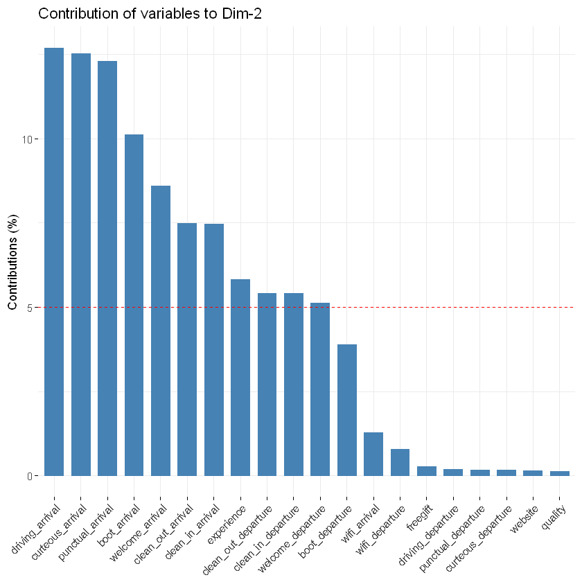

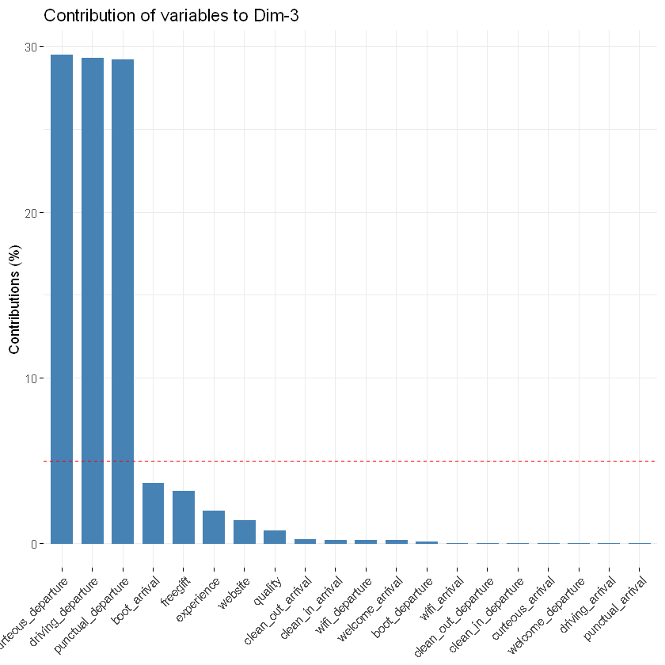

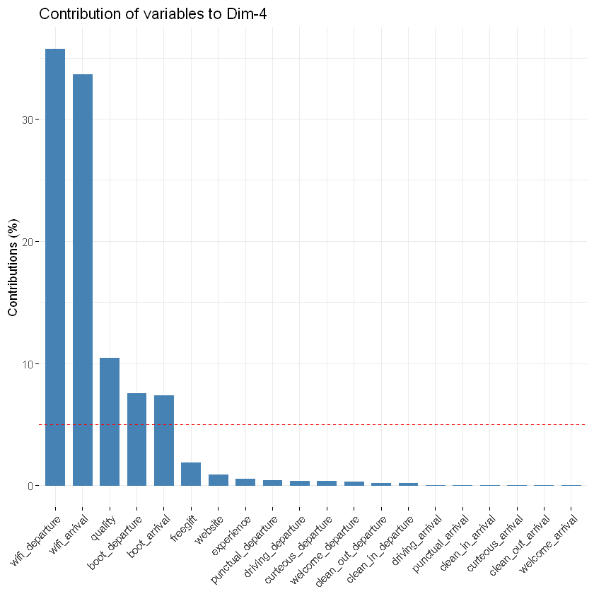

```r
varimax7 <- promax(pca$rotation[,1:4])
varimax7$loadings

fviz_contrib(pca, choice = "var", axes = 1, top = 20)
fviz_contrib(pca, choice = "var", axes = 2, top = 20)
fviz_contrib(pca, choice = "var", axes = 3, top = 20)
fviz_contrib(pca, choice = "var", axes = 4, top = 20)
```